# Analysis of MG63.3 YBX1 GUC6 C-terminal FLAG data

This document details the analysis of proteomics data acquired to compare MG63.3 GUC6 expressing FLAG tagged versions of YB-1 for interactomics. The raw MS data were compiled to peptide identifications using ProteomeDiscoverer.

## Setting up the environment

These are packages you will need for this notebook. For exact versions used, please refer to the session info at the bottom of this notebook.

```r
library('tidyverse')
library('ggplot2')
library('RColorBrewer')
library('vroom')
library('pheatmap')
library('ggrepel')
```

I want to set a base directory that we can use as a link to the directory where we will do most of the work. I use two directories here because the Workspace is what is pushed to GitHub and contains scripts and plot files, but the Repository is where more of the big data is stored that does not get pushed.

```r
generalDatasets = 'C:/Users/chughes/Documents/bccrc/projectsRepository/generalDatasets'
baseWorkspace = 'C:/Users/chughes/Documents/bccrc/projectsWorkspace/sorensenLab/relatedToYbx1'
baseRepository = 'C:/Users/chughes/Documents/bccrc/projectsRepository/sorensenLab/relatedToYbx1'
#generalDatasets = 'C:/Users/chris/OneDrive/Documents/bccrc/projectsRepository/generalDatasets'
#baseWorkspace = 'C:/Users/chris/OneDrive/Documents/bccrc/projectsWorkspace/sorensenLab/relatedToYbx1'
#baseRepository = 'C:/Users/chris/OneDrive/Documents/bccrc/projectsRepository/sorensenLab/relatedToYbx1'
```

## Data processing

Read the protein annotation details.

```r
##########################################################################################
proteinAnnotation = readRDS(paste(baseRepository, '/proteomics20200705_mg633CrisprYbx1GucClones/uniprotHumanJul2020.fasta.annotated.rds', sep = ''))
```

## C-terminal data

```r
##########################################################################################
psm = vroom(paste(baseRepository, '/proteomics20201023_mg633Ybx1Guc6Interaction/ch_20201022_mg633Ybx1Guc6FlagIpSet_TMT16_PSMs.txt', sep = '')) %>%
  dplyr::select(`Protein Accessions`, `Abundance 127N`, `Abundance 128N`, `Abundance 129N`, `Abundance 130N`, `Abundance 133N`:`Abundance 134N`) %>%
  mutate(accession = sapply(str_split(`Protein Accessions`, ';'), '[', 1)) %>%
  dplyr::select(accession, `Abundance 127N`:`Abundance 134N`) %>%
  left_join(proteinAnnotation) %>%
  dplyr::select(accession, gene, `Abundance 127N`:`Abundance 134N`) %>%
  filter(!grepl('^sp$', accession) | !is.na(gene)) %>%
  mutate(gene = gsub('-', NA, gene, fixed = TRUE)) %>%
  mutate(psms = 1)
```

[output not shown]

Filter the data to remove less confident PSMs.

```r
##########################################################################################
psmFiltered1 = subset(psm, rowSums(is.na(psm[,3:6])) < 2 & rowSums(is.na(psm[,7:9])) < 3)
psmFiltered2 = subset(psmFiltered1, rowSums(psmFiltered1[,3:6], na.rm = TRUE) > 40)
colnames(psmFiltered2)[3:9] = c('cYb1_1','cYb1_2','cYb1_3','cYb1_4','nGfp_1','nGfp_2','nGfp_3')
```

Roll the data into proteins.

```r
##########################################################################################
proPsms = psmFiltered2 %>%
  group_by(accession, gene) %>%
  summarise(numPsm = sum(psms, na.rm = TRUE))
pro = psmFiltered2 %>%
  group_by(accession, gene) %>%
  summarise(across(.cols = cYb1_1:nGfp_3, .fns = median, na.rm = TRUE)) %>%
  left_join(proPsms) %>%
  left_join(proteinAnnotation) %>%
  filter(!is.na(gene)) %>%
  arrange(-numPsm)
pro = subset(pro, rowSums(is.na(pro[,3:9])) < 1)
```

Now we can create the input files for SAINT analysis. First, create the ‘Bait’ file.

```r
##########################################################################################
baitMatrix = data.frame('ipName' = c('cYb1_1','cYb1_2','cYb1_3','cYb1_4','nGfp_1','nGfp_2','nGfp_3'),
                        'bait' = c('YBX1','YBX1','YBX1','YBX1','GFP_1','GFP_2','GFP_3'),
                        'type' = c('T','T','T','T','C','C','C'))
write.table(baitMatrix, paste(baseRepository, '/proteomics20201023_mg633Ybx1Guc6Interaction/yb1CterminalBaitFile.dat', sep = ''),
            col.names = FALSE, row.names = FALSE, quote = FALSE, sep = '\t')
```

Now can make the ‘Interaction’ file.

```r
##########################################################################################
interactionMatrix = ungroup(pro) %>%
  dplyr::select(accession, cYb1_1, cYb1_2, cYb1_3, cYb1_4, nGfp_1, nGfp_2, nGfp_3) %>%
  pivot_longer(cols = cYb1_1:nGfp_3, names_to = 'ipName', values_to = 'intensity') %>%
  filter(!is.na(intensity) & intensity > 0 & !grepl('P67809', accession)) %>%
  distinct()
interactionMatrix$baitName = ifelse(grepl('Yb1',interactionMatrix$ipName), 'YBX1', 'GFP')
interactionMatrix = dplyr::select(interactionMatrix, ipName, baitName, accession, intensity)
write.table(interactionMatrix, paste(baseRepository, '/proteomics20201023_mg633Ybx1Guc6Interaction/yb1CterminalInteractionFile.dat', sep = ''),
            col.names = FALSE, row.names = FALSE, quote = FALSE, sep = '\t')
```

Now create the ‘Prey’ file.

```r
##########################################################################################
preyMatrix = ungroup(pro) %>%
  dplyr::select(accession, gene, length, cYb1_1, cYb1_2, cYb1_3, cYb1_4, nGfp_1, nGfp_2, nGfp_3) %>%
  pivot_longer(cols = cYb1_1:nGfp_3, names_to = 'ipName', values_to = 'intensity') %>%
  filter(!is.na(intensity) & !grepl('P67809', accession)) %>%
  dplyr::select(accession, length, gene) %>%
  distinct()
write.table(preyMatrix, paste(baseRepository, '/proteomics20201023_mg633Ybx1Guc6Interaction/yb1CterminalPreyFile.dat', sep = ''),
            col.names = FALSE, row.names = FALSE, quote = FALSE, sep = '\t')
```

Run SAINTexpress with these files. For this I used the command ’/projects/ptx_analysis/chughes/software/SAINTexpress_v3.6.3__2018-03-09/Precompiled_binaries/Linux64/SAINTexpress-int -L 3 ./yb1CterminalInteractionFile.dat ./yb1CterminalPreyFile.dat ./yb1CterminalBaitFile.dat’.

Now we can import the output file from SAINT and make a plot.

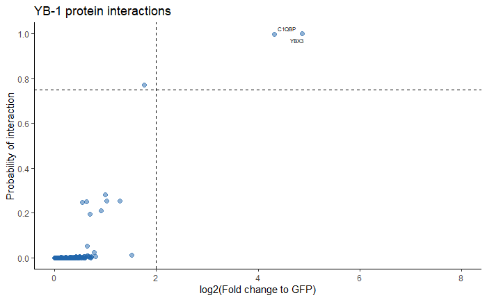

```r
##########################################################################################
saint = read_tsv(paste(baseRepository, '/proteomics20201023_mg633Ybx1Guc6Interaction/cTerminalYbx1SaintAnalysis.txt', sep = '')) %>%
  arrange(-SaintScore)
saint$pText = ifelse(saint$SaintScore > 0.75 & log2(saint$FoldChange) > 2, saint$PreyGene, '')
##
ggplot(saint, aes(log2(FoldChange), SaintScore)) +
  geom_point(size = 2, color = brewer.pal(8,'RdBu')[8], alpha = 0.5) +
  geom_text_repel(label = saint$pText, segment.size = 0.25, size = 2) +
  scale_x_continuous(limits = c(0,8), breaks = seq(0,8,2)) +
  scale_y_continuous(limits = c(0,1), breaks = seq(0,1,0.2)) +
  geom_vline(xintercept = 2, linetype = 'dashed') +
  geom_hline(yintercept = 0.75, linetype = 'dashed') +
  labs(x = 'log2(Fold change to GFP)', y = 'Probability of interaction', title = 'YB-1 protein interactions') +
  theme_classic()
ggsave(paste(baseRepository, '/proteomics20201023_mg633Ybx1Guc6Interaction/scatter_mg633Ybx1Guc6CflagSaint.pdf', sep = ''),
       height = 4,
       width = 4,
       useDingbats = FALSE)
```

[session information not shown]